# 高等数学 · 第12讲 · 定积分的概念与性质

## 定积分的概念与性质

高等数学 · 第 12 讲

第一小节

曲边梯形的面积

第二小节

定积分的定义

$$A=\lim\limits_{\lambda\to0}\sum_{i=1}^n f(\xi_i)\Delta x_i.$$

从面积和式出发 → 理解定积分 → 运用基本性质

## 刘徽割圆：用直边逼近曲边

刘徽 · 公元263年 · 《九章算术注》

从圆内接正六边形开始，**每次平分圆弧，使边数加倍**。

[figure not shown]

**“割之弥细，所失弥少。”**

边数越多，多边形与圆之间漏掉的面积越小。

## 内接与外切：把圆面积夹在中间

阿基米德 · 公元前3世纪 · 《圆的度量》

**内接正多边形少算，外切正多边形多算。**

[figure not shown]

$$S_{\text{内接}}\le S_{\text{圆}}\le S_{\text{外切}}.$$

边数沿 $6,12,24,\ldots$ 增加，两侧的面积差趋于 $0$。

## 阿基米德：抛物线弓形的面积

公元前3世纪 · 《抛物线求积》

取切线平行于斜弦 $AB$ 的点 $C$，记内接三角形 $ABC$ 的面积为 $T$。

[figure not shown]

每层新增的**总面积**是上一层的 $\dfrac14$：

$$S=T+\dfrac T4+\dfrac T{16}+\cdots=\dfrac43T.$$

## 回顾：三角形与扇形

单位圆中，取 $0<x<1$，$t=\angle QOP=\arcsin x$，角度以弧度计。

[figure not shown]

**绿色三角形 $OHP$**

$$S_{\triangle}=\dfrac x2\sqrt{1-x^2}.$$

**棕色扇形 $OQP$**

$$S_{\text{扇形}}=\dfrac t2=\dfrac12\arcsin x.$$

$$\displaystyle \int\sqrt{1-x^2}\,\mathrm dx
=\underbrace{\dfrac x2\sqrt{1-x^2}}_{\text{三角形}}
+\underbrace{\dfrac12\arcsin x}_{\text{扇形}}+C.$$

不定积分的结果要加任意常数 $C$。

## 曲边梯形的面积

第一小节

$$A=\lim\limits_{\lambda\to0}\sum_{i=1}^{n}f(\xi_i)\Delta x_i.$$

分割 → 近似代替 → 求和 → 取极限

## 曲边梯形的面积

设 $f(x)$ 在 $[a,b]$ 上连续，且 $f(x)\ge0$，其中 $a<b$。

由曲线 $y=f(x)$、直线 $x=a$、$x=b$ 和 $x$ 轴围成的图形，称为**曲边梯形**。

[figure not shown]

**抛物线：** $y=x^2+1,\qquad a=-1,\quad b=1$。

[figure not shown]

**正态曲线（均值为 $0$）：** $y=\dfrac{1}{\sigma\sqrt{2\pi}}e^{-\frac{x^2}{2\sigma^2}},\quad\sigma>0$。

[figure not shown]

## 奶龙铺瓷砖：怎样算面积？

[video not shown]

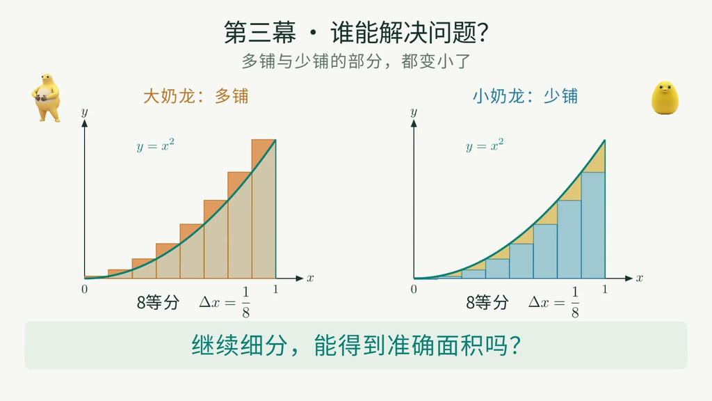

## 让矩形越来越细

将 $[0,1]$ 等分，用矩形逼近 $y=x^2$ 下方的面积。

等分数 n

当前：右端点，n = 4

每段宽度 0.25

| 取点 | 面积和 |
| --- | --- |
| 左端点 | 0.218750 |
| 右端点 | 0.468750 |

模型 y = x²，x ∈ [0, 1]；横纵坐标均无量纲。青色表示当前矩形面积和。

[figure not shown]

四等分时：左端点和为 $0.218750$，右端点和为 $0.468750$。

## 用下和与上和求面积

设 $A$ 为 $y=x^2$ 在 $[0,1]$ 上的曲边梯形面积。将区间等分为 $n$ 段，每段宽 $\dfrac1n$。

**下和** 取左端点

$$\begin{aligned}
L_n&=\sum_{i=1}^{n}\left(\dfrac{i-1}{n}\right)^2\dfrac1n\\
&=\dfrac{(n-1)(2n-1)}{6n^2}.
\end{aligned}$$

$$\lim\limits_{n\to\infty}L_n=\dfrac16\cdot1\cdot2=\dfrac13.$$

**上和** 取右端点

$$\begin{aligned}
U_n&=\sum_{i=1}^{n}\left(\dfrac in\right)^2\dfrac1n\\
&=\dfrac{(n+1)(2n+1)}{6n^2}.
\end{aligned}$$

$$\lim\limits_{n\to\infty}U_n=\dfrac16\cdot1\cdot2=\dfrac13.$$

$x^2$ 在 $[0,1]$ 上递增，下和不超过面积，上和不小于面积：

$$L_n\le A\le U_n.$$

由**夹逼定理**，得 $\boxed{A=\dfrac13}$。

## 从面积到和式的四步

[video not shown]

**① 分割**

$$a=x_0<x_1<\cdots<x_n=b,$$

$$\Delta x_i=x_i-x_{i-1}.$$

**② 近似**

任取 $\xi_i\in[x_{i-1},x_i]$，

$$\Delta A_i\approx f(\xi_i)\Delta x_i.$$

**③ 求和**

$$A\approx S_n=\sum_{i=1}^{n}f(\xi_i)\Delta x_i.$$

**④ 取极限**

记 $\lambda=\max_i\Delta x_i$，则

$$A=\lim\limits_{\lambda\to0}S_n.$$

$\lambda\to0$ 要求**每个**小区间的长度都趋于零。

## 用面积和式求面积

**例题 1**

用“分割、近似、求和、取极限”的方法，求曲线 $y=x^3$、直线 $x=0$、$x=1$ 与 $x$ 轴围成的图形的面积 $A$。

**Hint:** $\displaystyle\sum_{i=1}^{n}i^3=\left[\dfrac{n(n+1)}2\right]^2$。

[figure not shown]

解

将 $[0,1]$ 等分成 $n$ 段，取右端点的函数值作矩形的高：

$$\Delta x_i=\frac1n,\qquad\xi_i=\frac in.$$

$$S_n=\sum_{i=1}^{n}\left(\dfrac in\right)^3\dfrac1n
=\dfrac1{n^4}\sum_{i=1}^{n}i^3
=\dfrac{(n+1)^2}{4n^2}.$$

$$A=\lim\limits_{n\to\infty}S_n
=\lim\limits_{n\to\infty}\dfrac14\left(1+\dfrac1n\right)^2
=\boxed{\dfrac14}.$$

## 从和式识别曲边梯形

独立作答 · 3 分钟

**练习题 1** 下列和式极限分别表示哪个曲边梯形的面积？无需求值。

1. $\displaystyle\lim\limits_{n\to\infty}\sum_{i=1}^{n}\left(1+\frac in\right)^2\frac1n$；
2. $\displaystyle\lim\limits_{n\to\infty}\sum_{i=1}^{n}\sqrt{1+\left(\frac{2i}{n}\right)^2}\,\frac2n$。

解

(1)

[figure not shown]

(2)

[figure not shown]

## 定积分的定义

第二小节

$$\displaystyle \int_a^b f(x)\,\mathrm dx$$

定义与可积性 · 几何意义 · 基本性质

## 定积分的定义

设 $a<b$，函数 $f(x)$ 在 $[a,b]$ 上有界。

**定义 1**

任意分割 $a=x_0<\cdots<x_n=b$，在每段中任取 $\xi_i\in[x_{i-1},x_i]$。记

$$\begin{aligned}
\Delta x_i&=x_i-x_{i-1},\\
\lambda&=\max_i\Delta x_i.
\end{aligned}$$

[figure not shown]

若当 $\lambda\to0$ 时，无论怎样分割和取点，黎曼和 $\displaystyle\sum_{i=1}^{n}f(\xi_i)\Delta x_i$ 都趋于**同一个有限极限** $I$，则称 $f$ 在 $[a,b]$ 上可积，并定义

$$\displaystyle \boxed{\displaystyle \int_a^b f(x)\,\mathrm dx
=\lim\limits_{\lambda\to0}\sum_{i=1}^{n}f(\xi_i)\Delta x_i=I}.$$

$f(x)$：被积函数；$x$：积分变量；$a$：下限；$b$：上限。

## 再看铺瓷砖：不均匀分割

[video not shown]

**① 分割**

**不均匀分割**，四段宽分别为：

$$0.12,\quad0.22,\quad0.48,\quad0.18.$$

$$\Delta x_i=x_i-x_{i-1}.$$

**② 近似**

每段任取 $\xi_i\in[x_{i-1},x_i]$，

$$\text{矩形高度}=f(\xi_i).$$

矩形上边在本小区间内与曲线相交。

**③ 求和**

每块瓷砖的高乘自己的宽：

$$S_n=\sum_{i=1}^{n}f(\xi_i)\Delta x_i.$$

**④ 取极限**

瓷砖的**最大宽度**趋于零：

$$\lambda=\max_i\Delta x_i\to0.$$

$$\lim\limits_{\lambda\to0}S_n=\displaystyle\int_0^1x^2\,dx=\dfrac13.$$

## 非等分时怎样求和

独立作答 · 3 分钟

**练习题 2** 设 $f(x)=x^2$，在 $[0,2]$ 上取分点及样点：

$$x_0=0,\quad x_1=\dfrac14,\quad x_2=1,\quad x_3=2;$$

$$\xi_1=\dfrac18,\quad \xi_2=\dfrac12,\quad \xi_3=\dfrac32.$$

1. 求 $\Delta x_1,\Delta x_2,\Delta x_3$ 与 $\lambda$。
2. 求此次分割的黎曼和 $\displaystyle\sum_{i=1}^3 f(\xi_i)\Delta x_i$。

解

1. $\displaystyle(\Delta x_1,\Delta x_2,\Delta x_3)=\left(\dfrac14,\dfrac34,1\right)$，$\lambda=1$。
2. $\displaystyle\left(\dfrac18\right)^2\dfrac14+\left(\dfrac12\right)^2\dfrac34+\left(\dfrac32\right)^2\cdot1=\dfrac{625}{256}$。

## 定积分得到什么？

| 比较 | 不定积分 | 定积分 |
| --- | --- | --- |
| 记号 | $\displaystyle\int f(x)\,\mathrm dx$ | $\displaystyle\int_a^b f(x)\,\mathrm dx$ |
| 结果 | **一族原函数** $F(x)+C$ | 固定区间上的**一个数** |
| 例子 | $\displaystyle\int x^2\,\mathrm dx=\dfrac{x^3}{3}+C$ | $\displaystyle\int_0^1 x^2\,\mathrm dx=\dfrac13$ |

## 哪些函数一定可积？

**定理 1 (可积的充分条件)**

1. 若 $f(x)$ 在闭区间 $[a,b]$ 上**连续**，则 $f$ 在该区间上可积。
2. 若 $f(x)$ 在 $[a,b]$ 上**有界**，且只有**有限个间断点**，则 $f$ 在该区间上可积。

**连续的例子**

$f(x)=x^2$，$x\in[0,1]$。

[figure not shown]

**有跳跃的例子**

$$f(x)=\begin{cases}1,&0\le x<1,\\3,&1\le x\le2.\end{cases}$$

[figure not shown]

## 不可积的两个例子

在 $[0,1]$ 上讨论黎曼积分。

**① 无界函数**

$$f(x)=\begin{cases}
\dfrac1x,&0<x\le1,\\
0,&x=0.
\end{cases}$$

[figure not shown]

**无界 → 不可积**

**② 狄利克雷函数**

$$D(x)=\begin{cases}
1,&x\text{ 为有理数},\\
0,&x\text{ 为无理数}.
\end{cases}$$

[figure not shown]

**极限不唯一 → 不可积**

## 定积分的几何意义

以下均设 $a<b$；$A_+$、$A_-$ 分别表示 $x$ 轴上、下方图形的面积。

[figure not shown]

**$f\ge0$**

$$\displaystyle \int_a^b f(x)\,\mathrm dx=A_+.$$

**$f\le0$**

$$\displaystyle \int_a^b f(x)\,\mathrm dx=-A_-.$$

**有正有负**

$$\displaystyle \int_a^b f(x)\,\mathrm dx=A_+-A_-.$$

## 正负面积相抵

**例题 2** 利用几何意义说明 $\displaystyle\int_0^{2\pi}\sin x\,\mathrm dx=0$。

[figure not shown]

**练习题 3** $\displaystyle\int_0^{2\pi}2\sin x\,\mathrm dx=\,?$

## 由图形求积分

独立作答 · 3 分钟

**练习题 4** 根据图形计算：

(1) $\displaystyle\int_{-1}^{1}|x|\,\mathrm dx$。

[figure not shown]

(2) $\displaystyle\int_{-1}^{1}\sqrt{1-x^2}\,\mathrm dx$。

[figure not shown]

解

1. 两个直角三角形：$\displaystyle\frac12\cdot1\cdot1\times2=\boxed{1}$。
2. 半径为 $1$ 的上半圆：$\displaystyle\frac12\pi\cdot1^2=\boxed{\frac\pi2}$。

## 积分限的两个约定

**上下限相同：**

$$\displaystyle \int_a^a f(x)\,\mathrm dx=0.$$

**交换上下限：**

$$\displaystyle \int_b^a f(x)\,\mathrm dx=-\int_a^b f(x)\,\mathrm dx.$$

例如：$\displaystyle\int_1^0 x^2\,\mathrm dx=-\frac13$。

## 线性与常数积分

以下各积分均存在，$\alpha$、$\beta$、$c$ 为常数。

**定理 2 (线性性质)**
$$\displaystyle \int_a^b[\alpha f(x)+\beta g(x)]\,\mathrm dx
=\alpha\int_a^b f(x)\,\mathrm dx+\beta\int_a^b g(x)\,\mathrm dx.$$

**推论 1 (常数积分)**
$$\displaystyle \int_a^b 1\,\mathrm dx=b-a,\qquad
\boxed{\displaystyle \int_a^b c\,\mathrm dx=c(b-a)}.$$

黎曼和中可以提取常数、按项相加；取极限后仍保留这些运算规则。

## 线性与换限

独立作答 · 4 分钟

**练习题 5** 已知

$\displaystyle\int_1^3 f(x)\,\mathrm dx=2$

$\displaystyle\int_1^3 g(x)\,\mathrm dx=-1$

求下列定积分：

1. $\displaystyle\int_1^3[3f(x)-2g(x)+1]\,\mathrm dx$；
2. $\displaystyle\int_3^1[3f(x)-2g(x)+1]\,\mathrm dx$。

解

1. $\displaystyle 3\times2-2\times(-1)+(3-1)=\boxed{10}$。
2. 交换上下限后变号，得 $\displaystyle\boxed{-10}$。

常数项 $1$ 的积分贡献是区间长度 $2$。

## 用积分条件确定常数

独立作答 · 3 分钟

**练习题 6** 设 $f$ 在 $[0,2]$ 上可积，且 $\displaystyle\int_0^2 f(x)\,\mathrm dx=3$。

1. 若 $\displaystyle\int_0^2[af(x)+2]\,\mathrm dx=1$，求常数 $a$。
2. 求 $\displaystyle\int_2^0[2f(x)-1]\,\mathrm dx$。

解

1. $3a+2(2-0)=1$，所以 $\boxed{a=-1}$。
2. $\displaystyle\int_2^0[2f(x)-1]\,\mathrm dx=-[2\times3-(2-0)]=\boxed{-4}$。

## 积分区间可以拆开

**定理 3 (区间可加性)** 设 $f$ 在包含 $a,b,c$ 的区间上可积，则

$$\displaystyle \boxed{\displaystyle \int_a^b f(x)\,\mathrm dx
=\int_a^c f(x)\,\mathrm dx+\int_c^b f(x)\,\mathrm dx}.$$

[figure not shown]

结合换限约定，公式对 $a,b,c$ 的其他排列也成立。

## 拆分区间求积分

独立作答 · 4 分钟

**练习题 7** 已知 $f$ 在 $[0,3]$ 上可积，且 $\displaystyle\int_0^3 f(x)\,\mathrm dx=7$，$\displaystyle\int_1^3 f(x)\,\mathrm dx=5$，求：

1. $\displaystyle\int_0^1 f(x)\,\mathrm dx$；
2. $\displaystyle\int_3^1[f(x)-2]\,\mathrm dx$。

解

1. $\displaystyle\int_0^1 f(x)\,\mathrm dx=7-5=\boxed{2}$。
2. $\displaystyle\int_3^1[f(x)-2]\,\mathrm dx=-5-2(1-3)=\boxed{-1}$。

先确定所需区间，再处理积分方向和常数项。

## 用定义计算正弦积分

**例题 3** 用定积分定义计算 $\displaystyle I=\int_0^\pi\sin x\,\mathrm dx$。

解

**① 取中点**：$\sin x$ 连续。令 $h=\dfrac\pi n$，取 $\xi_i=\left(i-\dfrac12\right)h$。

**② 求和相消**：

$$2\sin\dfrac h2\,\sin\xi_i
=\cos((i-1)h)-\cos(ih).$$

$$S_n=h\sum_{i=1}^n\sin\xi_i
=\dfrac{h(\cos0-\cos\pi)}{2\sin(h/2)}
=\dfrac{h}{\sin(h/2)}.$$

**③ 取极限**：利用 $\sin t\sim t$（$t\to0$）。

$$I=\lim\limits_{n\to\infty}S_n
=2\lim\limits_{h\to0^+}\dfrac{h/2}{\sin(h/2)}
=\boxed{2}.$$

## 作业12

作业 1

1. 根据定义计算 $\displaystyle\int_0^1x\,\mathrm dx$。

   **提示：** 可用 $\displaystyle\sum_{i=1}^{n}i=\dfrac{n(n+1)}{2}$。
2. 根据几何意义求值：
   1. $\displaystyle\int_0^{2\pi}\cos x\,\mathrm dx$；
   2. $\displaystyle\int_{-2}^{2}\sqrt{4-x^2}\,\mathrm dx$。
3. 设 $f$ 在 $[0,5]$ 上可积，已知

   $$\displaystyle \int_0^2f(x)\,\mathrm dx=3,\quad
   \int_2^5f(x)\,\mathrm dx=-1.$$

   求 $\displaystyle\int_5^0[2f(x)+1]\,\mathrm dx$。

作业 2

4. 说明下列极限表示哪个曲边梯形的面积，无需求值：

   $$\displaystyle\lim\limits_{n\to\infty}\sum_{i=1}^{n}\left(2+\dfrac{3i}{n}\right)^2\dfrac3n.$$